# MissForest Data Imputation

For my data science insight this week, I was inspired by the zero cell problem and wanted to try and tackle an imputation method to address this issue. I decided to research and implement `missForest`, a random forest approach to data imputation from 2011 that often gets compared to k-nearest neighbors (KNN) imputations.

I modified the R implementation found [here](https://it.unt.edu/sites/default/files/missforest_l_jds_july2014.pdf) for easier demonstration purposes.

First, we create these example datasets.

```r
super_real_data <- matrix(c(51,43,22,92,28,21,68,22,9, 89, 67, 25, 75, 70, 55),ncol=3,byrow=TRUE)
colnames(super_real_data) <- c("High","Middle","Low")
rownames(super_real_data) <- c("Group 1","Group 2","Group 3","Group 4","Group 5")
super_real_data <- as.table(super_real_data)

super_real_data_missing <- matrix(c(51,NA,22,92,28,21,68,22,9, 89, 67, NA, 75, 70, 55),ncol=3,byrow=TRUE)
colnames(super_real_data_missing) <- c("High","Middle","Low")
rownames(super_real_data_missing) <- c("Group 1","Group 2","Group 3","Group 4","Group 5")
super_real_data_missing <- as.table(super_real_data_missing)

prop_missing <- length(which(is.na(super_real_data_missing) == "TRUE")) / (nrow(super_real_data_missing)*ncol(super_real_data_missing))
```

The first one `super_real_data` has no missing values and the second `super_real_data_missing` has missing values that we want to impute. The proportion of missing values is `0.1333333`.

```r
library(missForest)

output_1 <- missForest(xmis = super_real_data_missing, maxiter = 3, ntree = 10)
```

`xmis` is the dataset for which we want to impute missing values, `maxiter` is the maximum amount of times we want to iterate through the missing data, adjusting machine learning weights each time, and `ntree` refers to the number of trees to grow in each forest.

Here is our original dataset with missing values:

```r
super_real_data_missing
```

```
        High Middle Low
Group 1   51         22
Group 2   92     28  21
Group 3   68     22   9
Group 4   89     67
Group 5   75     70  55
```

Here it is now that we have filled it in with our random forest model data imputations:

```r
output_1$ximp
```

```
        High Middle  Low
Group 1 51.0   29.2 22.0
Group 2 92.0   28.0 21.0
Group 3 68.0   22.0  9.0
Group 4 89.0   67.0 41.4
Group 5 75.0   70.0 55.0
```

Finally, we can compare it to our original dataset:

```r
super_real_data
```

```
        High Middle Low
Group 1   51     43  22
Group 2   92     28  21
Group 3   68     22   9
Group 4   89     67  25
Group 5   75     70  55
```

Wow! Look at that! We imputed missing values that are *way* off from the actual values. Then again, we only gave our model 13 measurements to predict 2 additional measurements.

Typically, with more data, `missForest` has a very high success rate for data imputation, and as we showed here, it is relatively computationally inexpensive to implement. In comparison, KNN imputation is also a machine-learning, data imputation model, but it necessitates tuning the parameter k and is highly affected by outliers and other noise. In comparison, `missForest` is much less susceptible to noise. Studies have shown it also outperforms KNN with more accurate imputations (sometimes by up to 50%).

This graphic shows the `missForest` data imputation process at a high level:

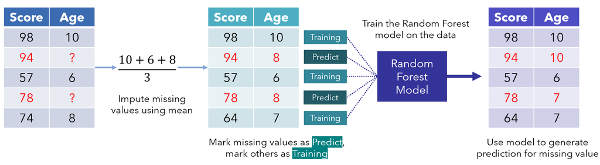

Tracing through this diagram, the empty values are replaced by the mean and marked as prediction parameters. This likely serves as a better starting point for training the model compared to replacing all empty cells with zero. All other values are marked as training parameters, and the values are inputted into the Random Forest model. The Random Forest model is trained on the data by incrementally changing the values until either an end condition is met of the number of iterations specified at the beginning is complete.

A final benefit of using `missForest` to impute data is its ability to handle both quantitative and qualitative data. Thus, `missForest` is a pretty effective out-of-the-box solution for data imputation.

Sources:  
https://towardsdatascience.com/missforest-the-best-missing-data-imputation-algorithm-4d01182aed3  
https://it.unt.edu/sites/default/files/missforest_l_jds_july2014.pdf  
https://cran.r-project.org/web/packages/missForest/missForest.pdf  
https://www.cyclismo.org/tutorial/R/tables.html